# TP Estadistica Descriptiva

Guido Freire

Analisis de avisos de properati en barrios de Buenos Aires

```r
ar_properties = read.csv('ar_properties.csv', stringsAsFactors = FALSE)
head(ar_properties)
```

|  | id | ad_type | start_date | end_date | created_on | lat | lon | l1 | l2 | l3 | l4 | l5 | l6 | rooms | bedrooms | bathrooms | surface_total | surface_covered | price | currency | price_period | title | property_type | operation_type |
| --- | --- | --- | --- | --- | --- | --- | --- | --- | --- | --- | --- | --- | --- | --- | --- | --- | --- | --- | --- | --- | --- | --- | --- | --- |
| 1 | S0we3z3V2JpHUJreqQ2t/w== | Propiedad | 2019-04-14 | 2019-06-14 | 2019-04-14 | -34.94331 | -54.92966 | Uruguay | Maldonado | Punta del Este | NA | NA | NA | 2 | NA | 1 | 45 | 40 | 13000 | UYU | Mensual | Departamento - Roosevelt | Departamento | Alquiler |
| 2 | kMxcmAS8NvrynGBVbMOEaQ== | Propiedad | 2019-04-14 | 2019-04-16 | 2019-04-14 | -34.63181 | -58.42060 | Argentina | Capital Federal | Boedo | NA | NA | NA | NA | NA | NA | NA | NA | 0 | NA | Mensual | PH - Boedo | PH | Venta |
| 3 | Ce3ojF+ZTOkB8d+LI9dpxg== | Propiedad | 2019-04-14 | 9999-12-31 | 2019-04-14 | NA | NA | Argentina | Bs.As. G.B.A. Zona Norte | NA | NA | NA | NA | 2 | NA | 1 | 200 | NA | NA | NA | NA | Ituzaingo 1100 - $ 1 - Casa Alquiler | Casa | Alquiler |
| 4 | AUGpj3raGmOCiulSMGIBPA== | Propiedad | 2019-04-14 | 9999-12-31 | 2019-04-14 | -34.65471 | -58.79089 | Argentina | Bs.As. G.B.A. Zona Oeste | Moreno | Moreno | NA | NA | 2 | NA | 2 | 460 | 100 | NA | NA | Mensual | Dr. Vera 300 - Consulte precio - Casa en Venta | Casa | Venta |
| 5 | m+MwZmJl3OoxmfWcB//sBA== | Propiedad | 2019-04-14 | 2019-07-09 | 2019-04-14 | -34.65495 | -58.78712 | Argentina | Bs.As. G.B.A. Zona Oeste | Moreno | Moreno | NA | NA | 2 | NA | 3 | 660 | 148 | NA | NA | Mensual | L. N. Alem 2400 - Consulte precio - Casa en Venta | Casa | Venta |
| 6 | pJRPrB5G8JlK9J3Yg5F+Hg== | Propiedad | 2019-04-14 | 2019-08-08 | 2019-04-14 | -32.93547 | -60.68398 | Argentina | Santa Fe | Rosario | NA | NA | NA | 4 | NA | 1 | NA | 89 | NA | NA | Mensual | Casa - Ludueña | Casa | Venta |

Estaria bueno ver que efectivamente los barrios que tengo que seleccionar existan y que el nombre que uso coincida con el de la base

```r
head(unique(ar_properties$l3))
```

```
## [1] "Punta del Este" "Boedo"          NA               "Moreno"
## [5] "Rosario"        "Ituzaingó"
```

```r
datos_barrios = ar_properties[is.element(ar_properties$l3, c("Boedo", "Colegiales", "Centro / Microcentro", "Mataderos", "Puerto Madero")),]
table(datos_barrios$l3)
```

```
##
##                Boedo Centro / Microcentro           Colegiales
##                 1155                 1848                 1844
##            Mataderos        Puerto Madero
##                 1185                 2463
```

```r
head(datos_barrios)
```

|  | id | ad_type | start_date | end_date | created_on | lat | lon | l1 | l2 | l3 | l4 | l5 | l6 | rooms | bedrooms | bathrooms | surface_total | surface_covered | price | currency | price_period | title | property_type | operation_type |
| --- | --- | --- | --- | --- | --- | --- | --- | --- | --- | --- | --- | --- | --- | --- | --- | --- | --- | --- | --- | --- | --- | --- | --- | --- |
| 2 | kMxcmAS8NvrynGBVbMOEaQ== | Propiedad | 2019-04-14 | 2019-04-16 | 2019-04-14 | -34.63181 | -58.42060 | Argentina | Capital Federal | Boedo | NA | NA | NA | NA | NA | NA | NA | NA | 0 | NA | Mensual | PH - Boedo | PH | Venta |
| 49 | WP1Nq9/ESbQYKMYdQryL1A== | Propiedad | 2019-04-14 | 2019-04-29 | 2019-04-14 | -34.57827 | -58.46255 | Argentina | Capital Federal | Colegiales | NA | NA | NA | NA | NA | 5 | 900 | 900 | 0 | NA | Mensual | Local de 1 ambiente en Alquiler en Colegiales | Local comercial | Alquiler |
| 50 | shKAu1QR+SzX487bMydFIA== | Propiedad | 2019-04-14 | 2019-04-29 | 2019-04-14 | -34.57555 | -58.43981 | Argentina | Capital Federal | Colegiales | NA | NA | NA | NA | NA | 5 | 2753 | 2753 | 0 | NA | Mensual | Local de 1 ambiente en Alquiler en Colegiales | Local comercial | Alquiler |
| 51 | NaxxEMzh1IfoBoO8ztlhWA== | Propiedad | 2019-04-14 | 2019-04-29 | 2019-04-14 | -34.57533 | -58.46353 | Argentina | Capital Federal | Colegiales | NA | NA | NA | NA | NA | 5 | 1350 | 1350 | 0 | NA | Mensual | Local de 1 ambiente en Alquiler en Colegiales | Local comercial | Alquiler |
| 91 | 3bEoPj/d6gzaFqFDmsWaWg== | Propiedad | 2019-04-14 | 2019-07-10 | 2019-04-14 | -34.57739 | -58.45630 | Argentina | Capital Federal | Colegiales | NA | NA | NA | NA | NA | 1 | 50 | 50 | 15000 | ARS | Mensual | PH EN ALQUILER | PH | Alquiler |
| 121 | AWjEkuPykUjCnrZM09CzTg== | Propiedad | 2019-04-14 | 2019-04-29 | 2019-04-14 | -34.61703 | -58.37037 | Argentina | Capital Federal | Centro / Microcentro | NA | NA | NA | NA | NA | 1 | 55 | 55 | 12800 | ARS | Mensual | Oficina de 1 ambiente en Alquiler en Centro | Oficina | Alquiler |

Inmediatamente veo filas con NA en “surface_total”, “surface_covered” y “rooms”, que son los atributos que me interesa analizar a continuacion (1).

```r
datos_barrios = datos_barrios[!is.na(datos_barrios$surface_total) &
                              !is.na(datos_barrios$surface_covered) &
                              !is.na(datos_barrios$rooms),]
```

# Tamaño de las propiedades

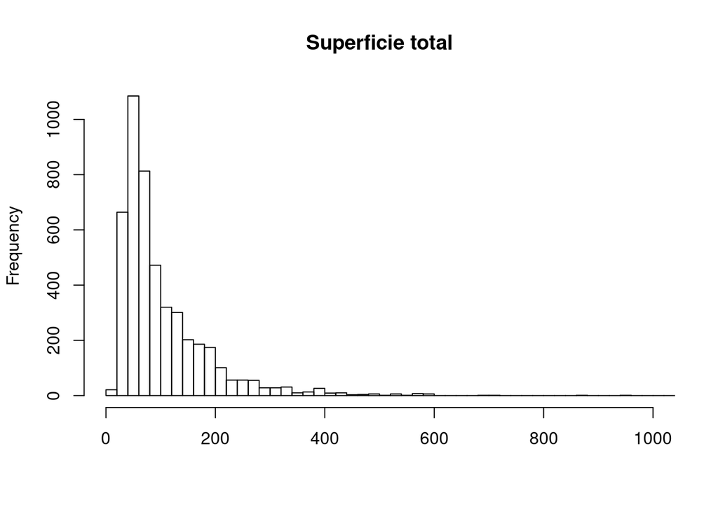

```r
hist(datos_barrios$surface_total, breaks = 300, xlab = "", main = "Superficie total", xlim = c(0, 1000))
```

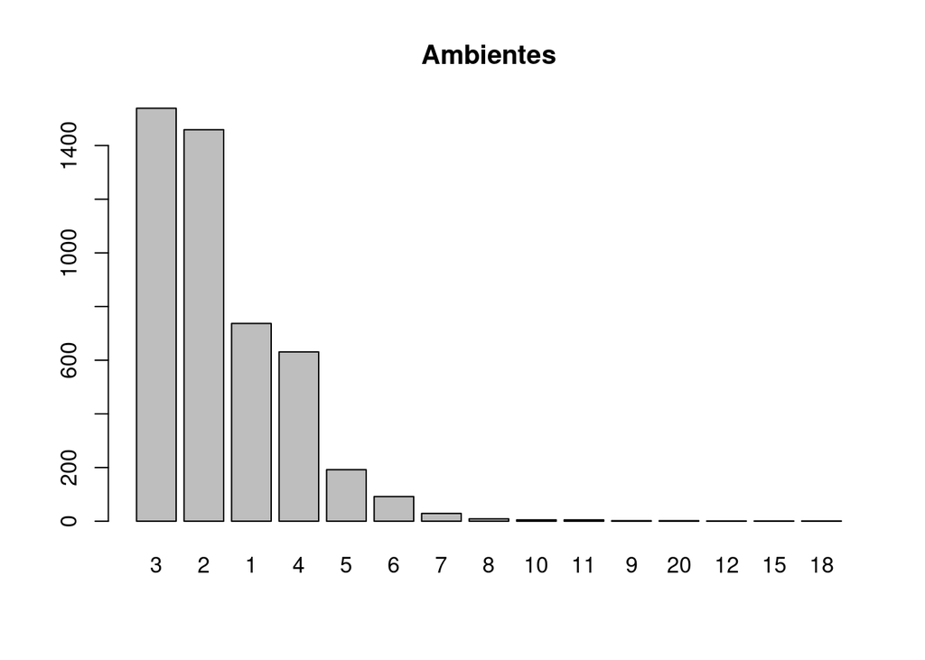

```r
barplot(sort(table(datos_barrios$rooms), decreasing = TRUE), main = "Ambientes")
```

Me interesaria comparar estos mismos atributos barrio a barrio (2).

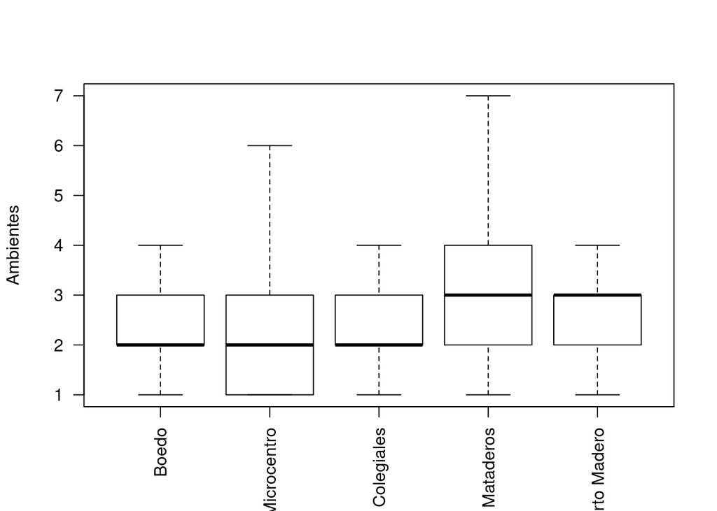

```r
boxplot(rooms ~ l3, data = datos_barrios, outline = FALSE, ylab = "Ambientes", xlab = "", las = 2)
```

Me animo a agrupar a Puerto Madero y Mataderos por un lado, y al resto de los barrios por otro, segun la cantidad de ambientes media ¿Se repetira esto cuando miro la superficie total por barri (4)?

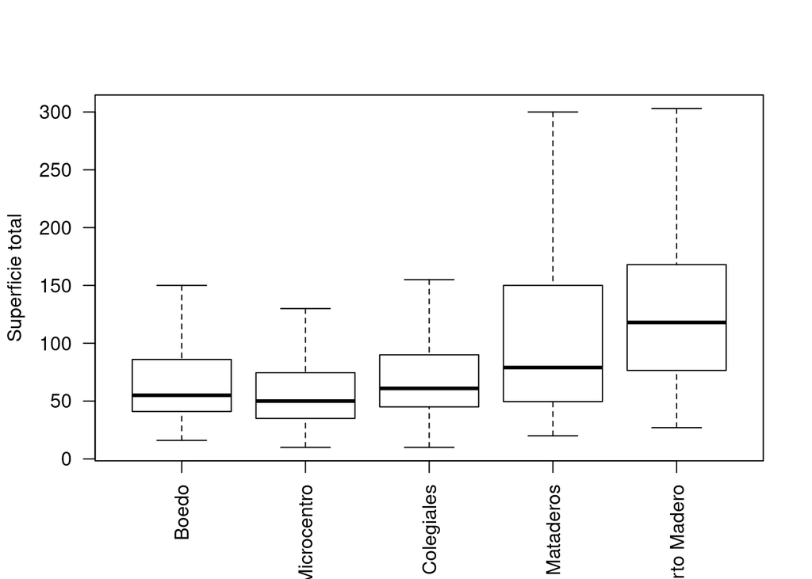

```r
boxplot(surface_total ~ l3, data = datos_barrios, outline = FALSE, ylab = "Superficie total", xlab = "", las = 2)
```

Aca no resulta tan obvio el agrupamiento, pero mirando los bigotes de Mataderos y Puerto Madero podria afirmarse que las propiedades tienen superficies mas dispersas. Cuantitativamente:

```r
aggregate(surface_total ~ l3, data = datos_barrios, IQR)
```

| l3 | surface_total |
| --- | --- |
| Boedo | 45.00 |
| Centro / Microcentro | 39.50 |
| Colegiales | 45.00 |
| Mataderos | 100.25 |
| Puerto Madero | 91.25 |

Efectivamente las distancias intercuartiles de Mataderos y Puerto Madero son bastante elevadas en relacion al resto de los barrios. Mido mas magnitudes descriptivas de superficie por barrio (3):

```r
resumen_barrio = aggregate(surface_total ~ l3, data = datos_barrios, summary, simplify = FALSE)
```

[output not shown]

En congruencia con el analisis anterior, las propiedades tipicas de Boedo, Centro y Colegiales comparten mucho mas que las propiedades tipicas de Mataderos y Puerto Madero. Intuitivamente la propiedad tipica de Mataderos deberia ser bastante distinta a la de Puerto Madero. El tamaño promedio de una habitacion podria ser una buena confirmacion de esto (5).

```r
aggregate(surface_covered / rooms ~ l3, data = datos_barrios, mean)
```

| l3 | surface_covered/rooms |
| --- | --- |
| Boedo | 27.71702 |
| Centro / Microcentro | 36.03573 |
| Colegiales | 27.85950 |
| Mataderos | 30.64527 |
| Puerto Madero | 43.51649 |

# Relación entre el precio y las características de una propiedad

Intento visualizar los precios de propiedades segun distintos atributos. Construyo una variable “fondo” (1, 2).

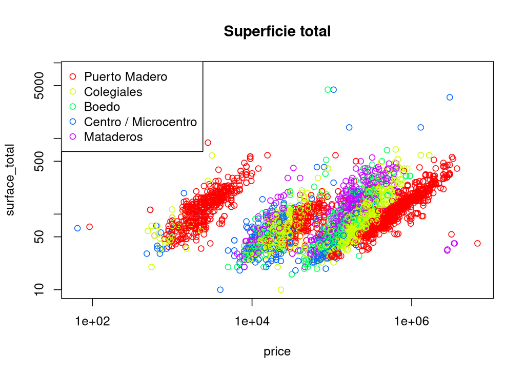

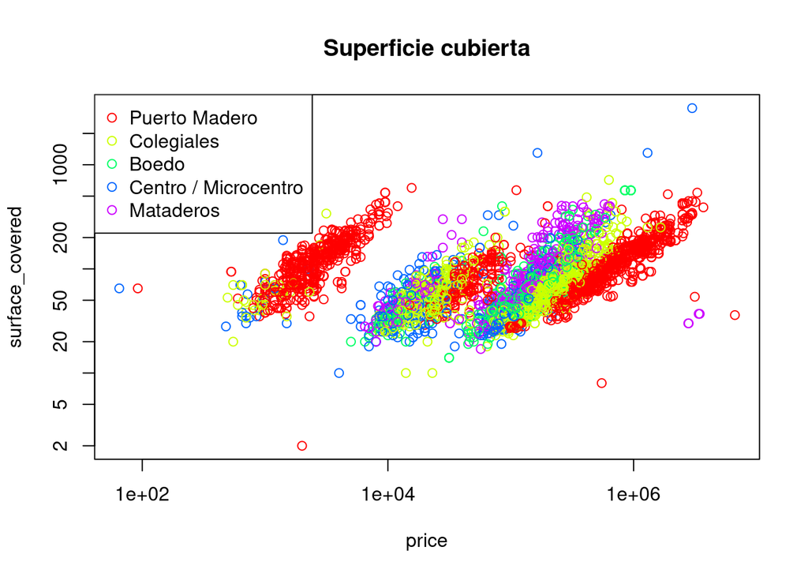

```r
fondo = datos_barrios$surface_total - datos_barrios$surface_covered

barrios = unique(datos_barrios$l3)
col_barrios = rainbow(length(barrios))
names(col_barrios) = barrios

plot(surface_total ~ price, data = datos_barrios, log="xy", col=col_barrios[datos_barrios$l3], main = "Superficie total")
legend("topleft", legend = barrios, col = col_barrios, pch = 1)
plot(surface_covered ~ price, data = datos_barrios, log="xy", col=col_barrios[datos_barrios$l3], main = "Superficie cubierta")
legend("topleft", legend = barrios, col = col_barrios, pch = 1)
```

Los graficos de superficie total y cubierta transmiten informacion muy parecida. Seria logico que el de fondo tambien lo haga.

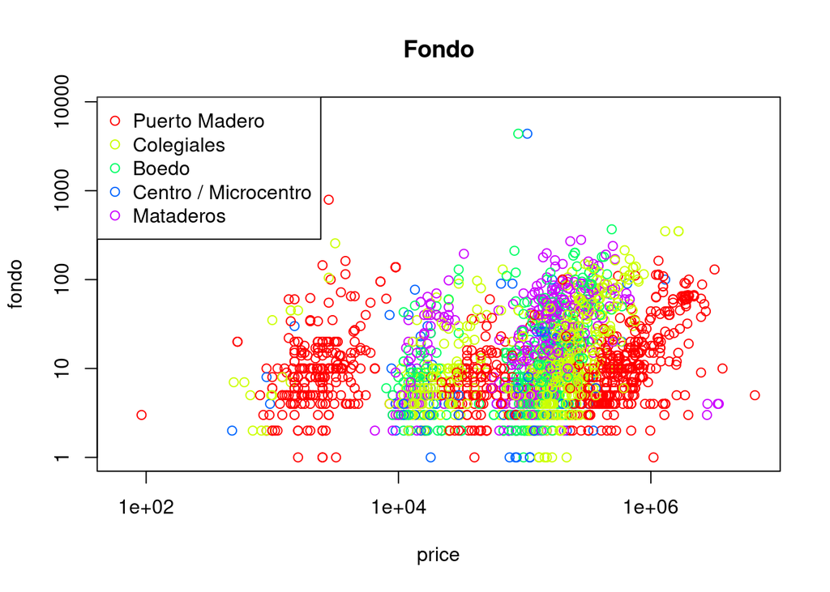

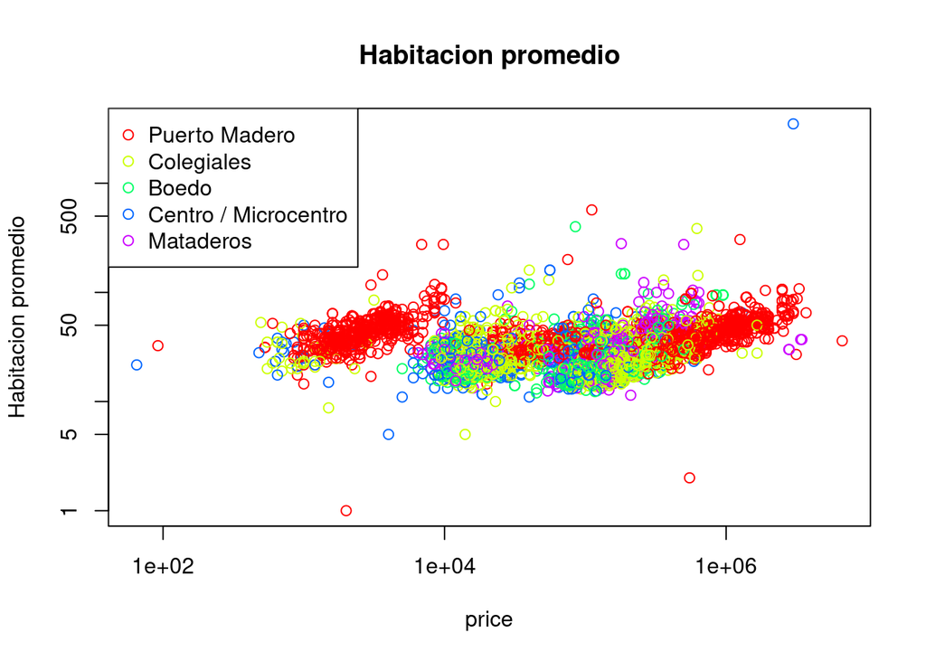

```r
plot(fondo ~ price, data = datos_barrios, log="xy", col=col_barrios[datos_barrios$l3], main = "Fondo")
legend("topleft", legend = barrios, col = col_barrios, pch = 1)
plot(surface_covered / rooms ~ price, data = datos_barrios, log="xy", col=col_barrios[datos_barrios$l3], ylab = "Habitacion promedio", main = "Habitacion promedio")
legend("topleft", legend = barrios, col = col_barrios, pch = 1)
```

Vale observar que las escalas horizontales y verticales son **logaritmicas**.

Para Puerto Madero hay distintas manchas bien definidas. Los graficos siguientes exploran a que se debe esto.

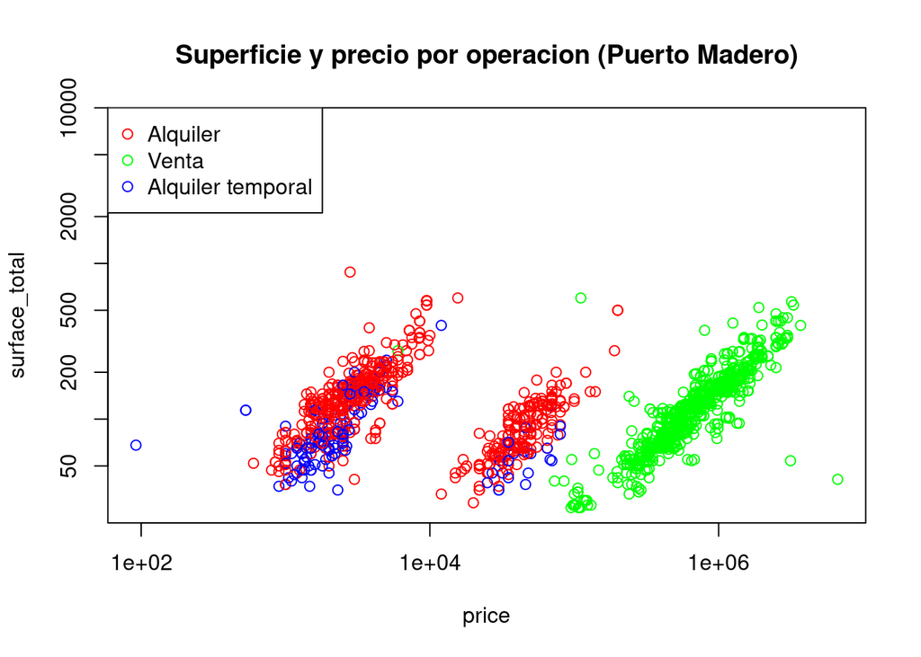

```r
operaciones = unique(datos_barrios$operation_type)
col_operaciones = rainbow(length(operaciones))
names(col_operaciones) = operaciones

datos_puerto = datos_barrios[datos_barrios$l3 == "Puerto Madero",]

plot(surface_total ~ price, data = datos_puerto, log = "xy", col = col_operaciones[datos_puerto$operation_type], main = "Superficie y precio por operacion (Puerto Madero)")
legend("topleft", legend = operaciones, col = col_operaciones, pch = 1)
```

Es clarisimo que el manchon “mas caro” de Puerto Madero se atribuye a las propiedades en venta. Quito las propiedades en alquiler del dataset para visualizar el precio por barrio con mayor claridad.

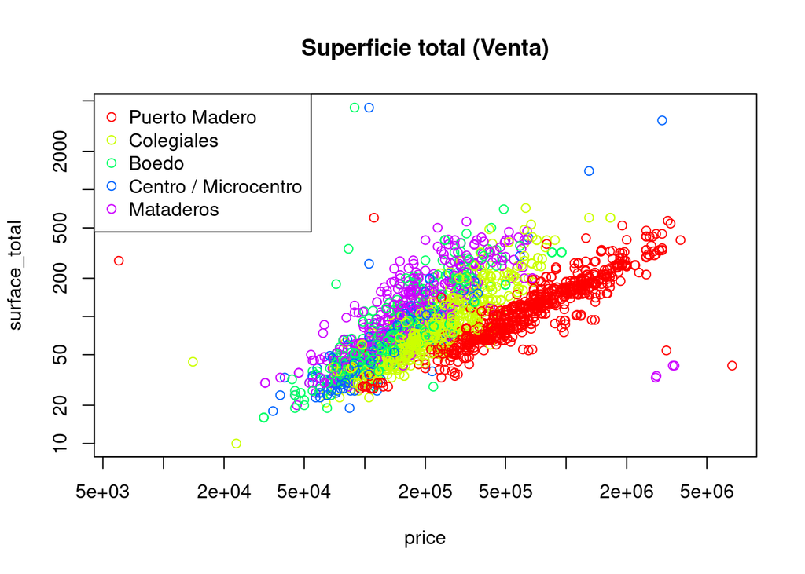

```r
datos_barrios = datos_barrios[datos_barrios$operation_type == "Venta",]
plot(surface_total ~ price, data = datos_barrios, log="xy", col=col_barrios[datos_barrios$l3], main = "Superficie total (Venta)")
legend("topleft", legend = barrios, col = col_barrios, pch = 1)
```

Ahora si son bien claras las diferencias de precio barrio a barrio. Exploro el precio por tipo de propiedad (3)

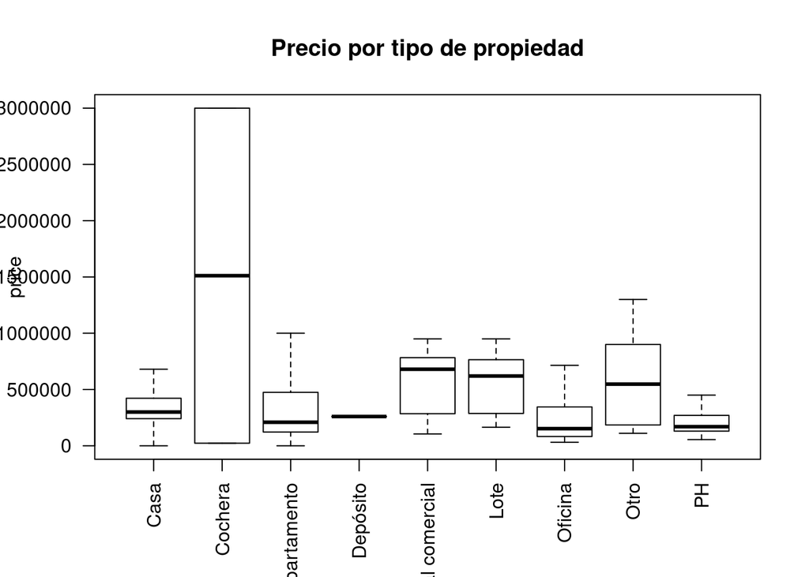

```r
boxplot(price ~ property_type, data = datos_barrios, outline = FALSE, las = 2, main = "Precio por tipo de propiedad", xlab = "")
```

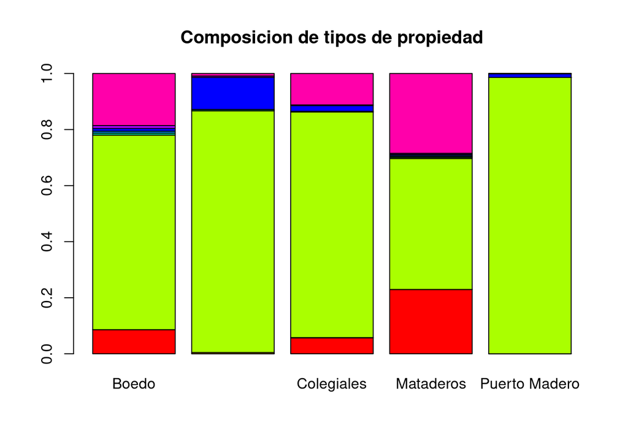

```r
propiedades = unique(datos_barrios$property_type)
col_propiedades = rainbow(length(propiedades))
names(col_propiedades) = propiedades

propbarrio = table(datos_barrios$property_type, datos_barrios$l3)
barplot(t(t(propbarrio) / colSums(propbarrio)), col = col_propiedades, main = "Composicion de tipos de propiedad", legend.text = FALSE, args.legend = list(x=6, y=6)) # (?) como ubicar leyenda, arreglar labels que no aparecen
```

Con esta informacion en mente, estaria bueno comparar lado a lado los graficos de superficie y precio por tipo de propiedad y barrio - dos formas distintas de agrupar la misma correlacion (4).

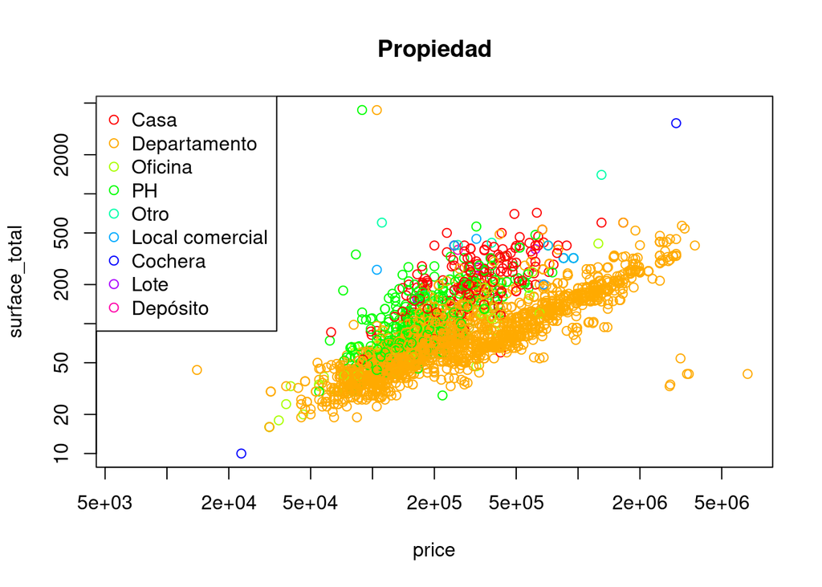

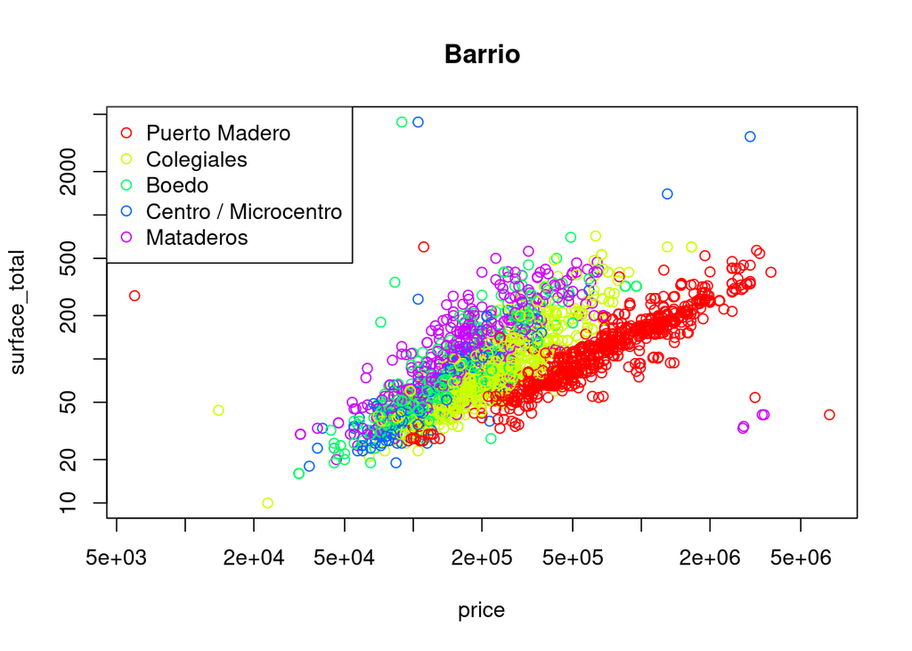

```r
plot(surface_total ~ price, data = datos_barrios, log="xy", col = col_propiedades[datos_barrios$property_type], main = "Propiedad")
legend("topleft", legend = propiedades, col = col_propiedades, pch = 1)

plot(surface_total ~ price, data = datos_barrios, log="xy", col=col_barrios[datos_barrios$l3], main = "Barrio")
legend("topleft", legend = barrios, col = col_barrios, pch = 1)
```

El tipo de propiedad ayuda a explicar el precio segun superficie total. Para departamentos la correlacion superficie / precio es particularmente fuerte. Los PH y las casas siguen una tendencia parecida; podria decirse que las casas son como PHs mas caros. Los departamentos suelen ser mas caros que los PH/casa.

Estas ideas no eran tan claras con el boxplot de precios por tipo de propiedad porque omite el factor de superficie.

# Conclusiones

Los ultimos dos graficos resumen, conjuntamente, una conclusion muy importante; para los mismos atributos, existe mas de una forma de agruparlos en clases bien definidas.

Puede decirse que Puerto Madero tiene las propiedades mas caras como podria decirse que los departamentos son las propiedades mas caras. Podria ser interestante analizar la causalidad de esto. En base al grafico de “Composicion de tipos de propiedad” Puerto Madero podria ser mas caro porque tiene la mayor proporcion de departamentos de todos los barrios. O son mas caros los departamentos porque estan todos en Puerto Madero?